# Part 2

2025-12-02

# Init

```r
library(emmeans)
library(multcomp)
library(lme4)
library(lmerTest)
```

```r
library(ggplot2)
library(dplyr)
library(predictmeans)
library(lattice) # to visualize random effects
library(nlme) # Rondom thingy
library(tidyr)
library(tidyverse)
# setwd("C:/Users/huste/Documents/Github/businessAnalytics/Correlated Data/Exam")
setwd("/home/husted42/Documents/github/businessAnalytics/Correlated Data/Exam/")

getwd()
```

```
## [1] "/home/husted42/Documents/github/businessAnalytics/Correlated Data/Exam"
```

```r
list.files()
```

```
## [1] "radon_code.html" "radon_code.Rmd"  "Radon_data.R"    "rat_code.Rmd"
## [5] "Rats_Box.txt"
```

```r
rats_short <- read.table("Rats_Box.txt", header = 1, sep = ",")
head(rats_short)
```

```
##   Rat Trt y0 y1 y2 y3 y4
## 1   1   1 57 29 28 25 33
## 2   2   1 60 33 30 23 31
## 3   3   1 52 25 34 33 41
## 4   4   1 49 18 33 29 35
## 5   5   1 56 25 23 17 30
## 6   6   1 46 24 32 29 22
```

# i) Prepare for analysis

We want to measure the gain of each rat, so our response variable should only be the gain y_0,…,y_4. But we need to use y_0 as an adjusting covariate in the model, ie. we should keep it as a feature. Practically this means that we filter out y_0, convert the data to long format, then join y_0 back again.

```r
# Pivot to long format
rats_long <- rats_short %>%
  pivot_longer(cols = starts_with("y"),
               names_to = "Week",
               values_to = "Value") %>%
  mutate(
    Week = as.numeric(substr(Week, 2, 2))
  ) %>%
  arrange(Rat, Week)

# Extract the first week
rats_y0 <- rats_long %>%
  dplyr::filter(Week == 0) %>%
  dplyr::select(Rat, Trt, y0 = Value)

# Filter out the first week
rats_gain <- rats_long %>%
  filter(Week != 0)

# Left join the y0 values
rats_long_gain <- rats_gain %>%
  left_join(rats_y0, by = c("Rat", "Trt"))

# NOTE : We should include y_0 in the report
rats <- rats_long_gain
rats$WeekQ <- rats$Week
rats$Week <- paste0("y", rats$Week)
rats$Rat <- as.factor(rats$Rat)
rats$Trt <- as.factor(rats$Trt)
rats$Week <- as.factor(rats$Week)
colnames(rats)[colnames(rats) == 'y0'] <- 'InitWheight'
colnames(rats)[colnames(rats) == 'Value'] <- 'Gain'
rats <- rats %>%
  dplyr::select(Rat, Trt, Week, WeekQ, InitWheight, Gain)

rats$InitWheight <- as.numeric(rats$InitWheight)
rats$Gain <- as.numeric(rats$Gain)

head(rats)
```

```
## # A tibble: 6 × 6
##   Rat   Trt   Week  WeekQ InitWheight  Gain
##   <fct> <fct> <fct> <dbl>       <dbl> <dbl>
## 1 1     1     y1        1          57    29
## 2 1     1     y2        2          57    28
## 3 1     1     y3        3          57    25
## 4 1     1     y4        4          57    33
## 5 2     1     y1        1          60    33
## 6 2     1     y2        2          60    30
```

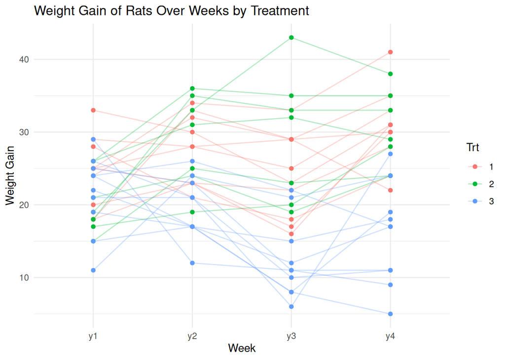

```r
ggplot(rats, aes(x = Week, y = Gain, color = Trt, group = Rat)) +
  geom_line(alpha = 0.3) +
  geom_point() +
  labs(title = "Weight Gain of Rats Over Weeks by Treatment",
       x = "Week",
       y = "Weight Gain") +
  theme_minimal()
```

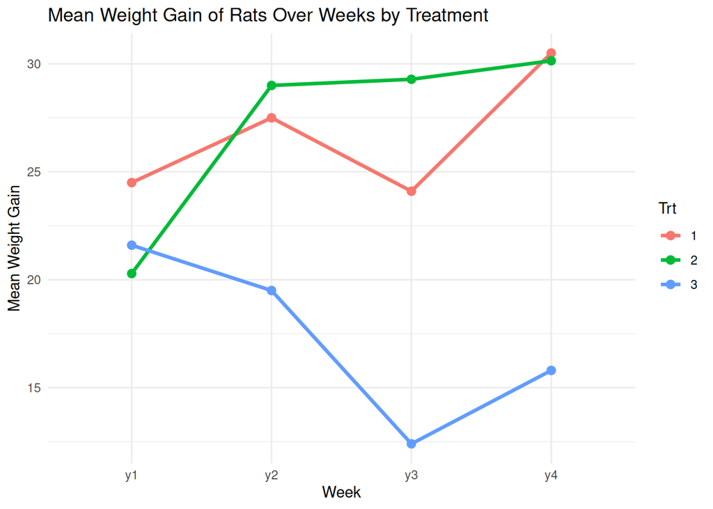

```r
ggplot(rats, aes(x = Week, y = Gain, color = Trt, group = Trt)) +
  stat_summary(fun = mean, geom = "line", size = 1.2) +
  stat_summary(fun = mean, geom = "point", size = 2.5) +
  labs(title = "Mean Weight Gain of Rats Over Weeks by Treatment",
       x = "Week",
       y = "Mean Weight Gain") +
  theme_minimal()
```

# ii) Do an exploratory analysis of the data, numerical and graphical

```r
#str(rats)
summary(rats$InitWheight)
```

```
##    Min. 1st Qu.  Median    Mean 3rd Qu.    Max.
##   46.00   51.00   56.00   54.67   59.00   63.00
```

```r
summary(rats$Gain)
```

```
##    Min. 1st Qu.  Median    Mean 3rd Qu.    Max.
##    5.00   18.00   24.00   23.33   29.00   43.00
```

When just looking at the distribution of gain, without accounting for treatment, the data look appproximatly nomrlal distributed.

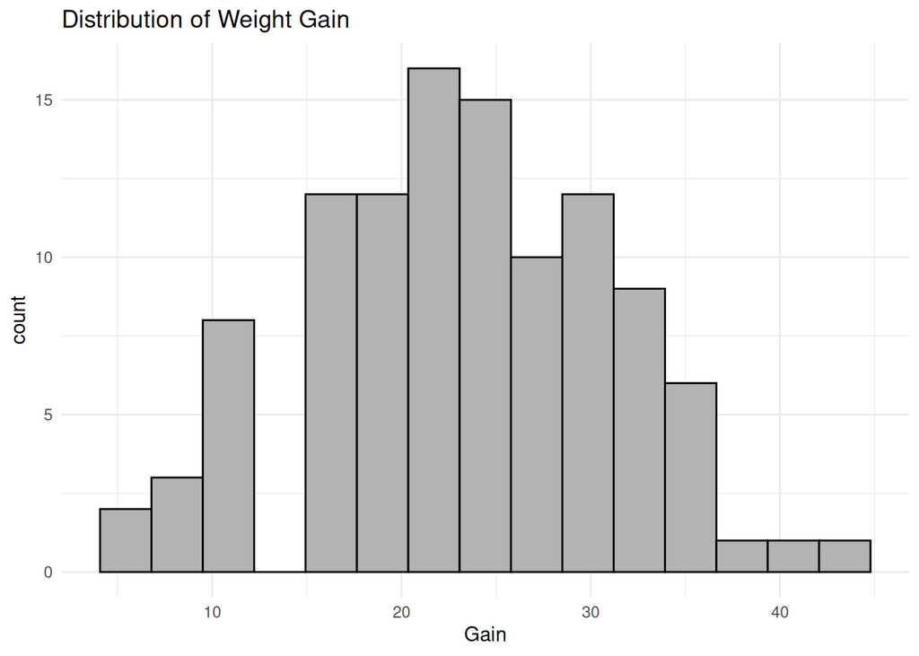

```r
ggplot(rats, aes(Gain)) +
  geom_histogram(bins = 15, color="black", fill="grey70") +
  theme_minimal() +
  labs(title = "Distribution of Weight Gain")
```

The within-treatment variability seems to be larger for treatments than the control group. The the difference in mean are smaller between control group and treatment-2, with a slight increase in quantiles ranges and variability. It not clear if the effect of treatment-2 is significant from the plot. However it looks like there is a noticeably difference between treatment-3 and the control group, which indicates that we the effect of treatment-3 is significant. But we cannot draw any conclusions.

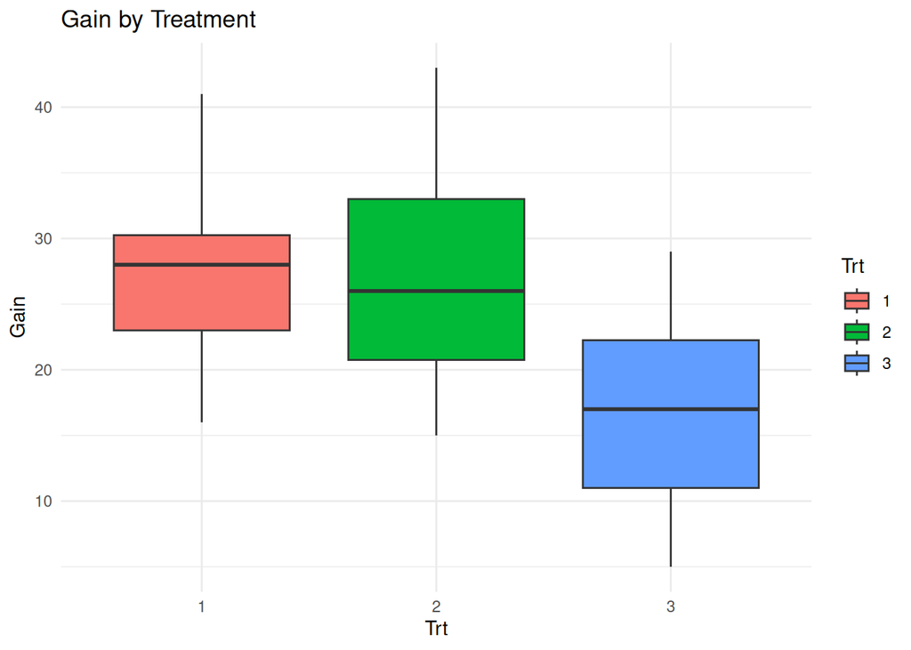

```r
ggplot(rats, aes(x = Trt, y = Gain, fill = Trt)) +
  geom_boxplot() +
  labs(title = "Gain by Treatment") +
  theme_minimal()
```

By this plot it doesn’t look like time alone has a significant effect on the increase in weights. Other than there seems to be an increase in the variability between week 1-2 and 3-4.

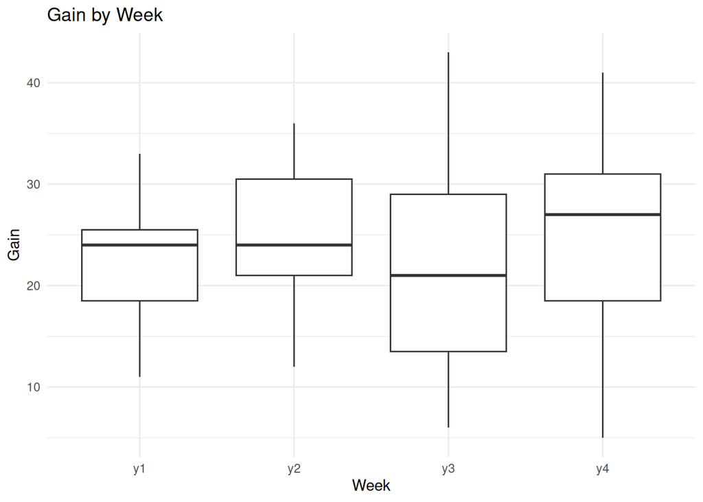

```r
ggplot(rats, aes(x = Week, y = Gain)) +
  geom_boxplot() +
  labs(title = "Gain by Week", x = "Week") +
  theme_minimal()
```

We check to see if there are correlations between the initial weights and gain. But with a correlation of 0.02, there is no clear evidence of this as is also seen in the figure.

```r
cor(rats$InitWheight, rats$Gain)
```

```
## [1] 0.02008826
```

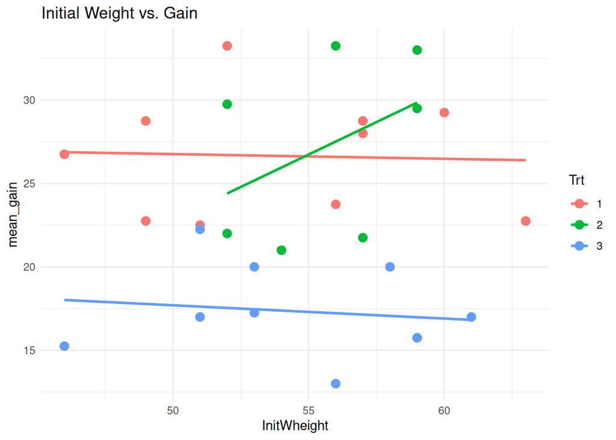

```r
rats %>%
  dplyr::group_by(Rat, Trt) %>%
  dplyr::summarise(mean_gain = mean(Gain), InitWheight = first(InitWheight), .groups = "drop") %>%
  ggplot(aes(x = InitWheight, y = mean_gain, color = Trt)) +
    geom_point(size = 3) +
    geom_smooth(method = "lm", se = FALSE) +
    theme_minimal() +
    labs(title = "Initial Weight vs. Gain")
```

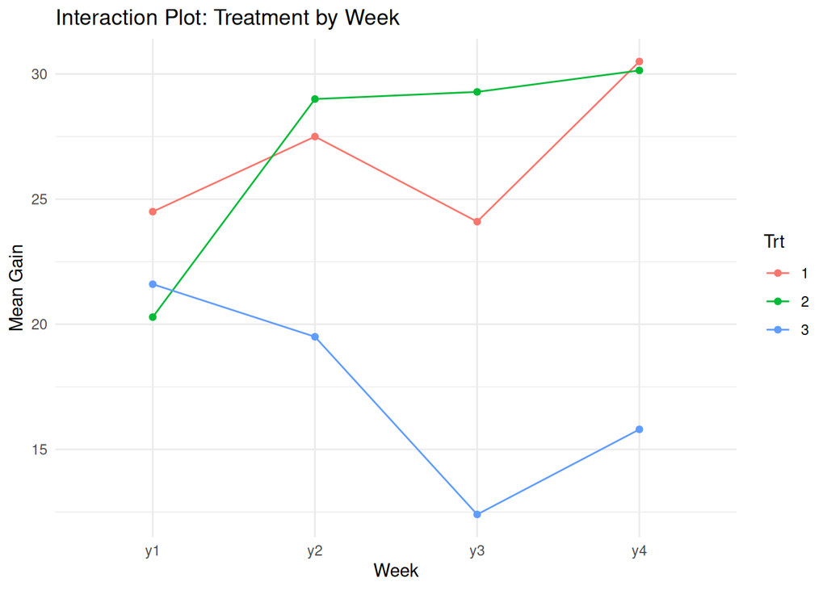

```r
ggplot(rats, aes(x = Week, y = Gain, color = Trt, group = Trt)) +
  stat_summary(fun = mean, geom = "line") +
  stat_summary(fun = mean, geom = "point") +
  labs(
    x = "Week",
    y = "Mean Gain",
    color = "Trt",
    title = "Interaction Plot: Treatment by Week"
  ) +
  theme_minimal()
```

# iii) Formulate a mixed model

We will build a mixed model from the button up, starting with the mean and a random effect for the rats ## Model 0 - Random effect

```r
mll_0 <- lmer(Gain ~ 1 + (1|Rat), data = rats)
ranova(mll_0)
```

```
## ANOVA-like table for random-effects: Single term deletions
##
## Model:
## Gain ~ (1 | Rat)
##           npar  logLik    AIC    LRT Df Pr(>Chisq)
## <none>       3 -363.09 732.17
## (1 | Rat)    2 -374.69 753.39 23.215  1  1.449e-06 ***
## ---
## Signif. codes:  0 '***' 0.001 '**' 0.01 '*' 0.05 '.' 0.1 ' ' 1
```

## Model 0.1 - InitWheight

```r
mll_0_1 <- lmer(Gain ~ InitWheight + (1|Rat), data = rats)
anova(mll_0_1)
```

```
## Type III Analysis of Variance Table with Satterthwaite's method
##              Sum Sq Mean Sq NumDF DenDF F value Pr(>F)
## InitWheight 0.62828 0.62828     1    25  0.0178 0.8949
```

## Model 1 - Adding treatment

```r
mll_1 <- lmer(Gain ~ Trt + (1|Rat), data = rats)
anova(mll_1)
```

```
## Type III Analysis of Variance Table with Satterthwaite's method
##     Sum Sq Mean Sq NumDF DenDF F value   Pr(>F)
## Trt 1347.7  673.83     2    24  19.097 1.09e-05 ***
## ---
## Signif. codes:  0 '***' 0.001 '**' 0.01 '*' 0.05 '.' 0.1 ' ' 1
```

## Model 2 - Adding fixed Week

```r
mll_2 <- lmer(Gain ~ Trt + Week + (1|Rat), data = rats)
anova(mll_2)
```

```
## Type III Analysis of Variance Table with Satterthwaite's method
##       Sum Sq Mean Sq NumDF DenDF F value   Pr(>F)
## Trt  1252.34  626.17     2    24 19.0973 1.09e-05 ***
## Week  300.52  100.17     3    78  3.0551  0.03325 *
## ---
## Signif. codes:  0 '***' 0.001 '**' 0.01 '*' 0.05 '.' 0.1 ' ' 1
```

## Model 3 - Adding interaction

```r
mll_3 <- lmer(Gain ~ Trt + factor(Week) + Trt:Week + (1|Rat), data = rats)
```

```
## fixed-effect model matrix is rank deficient so dropping 3 columns / coefficients
```

```r
anova(mll_3)
```

```
## Type III Analysis of Variance Table with Satterthwaite's method
##              Sum Sq Mean Sq NumDF  DenDF F value    Pr(>F)
## Trt           58.02  29.012     2 76.708  1.2683 0.2871507
## factor(Week) 495.87 165.292     3 72.000  7.2257 0.0002635 ***
## Trt:Week     910.45 151.742     6 72.000  6.6334 1.295e-05 ***
## ---
## Signif. codes:  0 '***' 0.001 '**' 0.01 '*' 0.05 '.' 0.1 ' ' 1
```

### Diagnostic

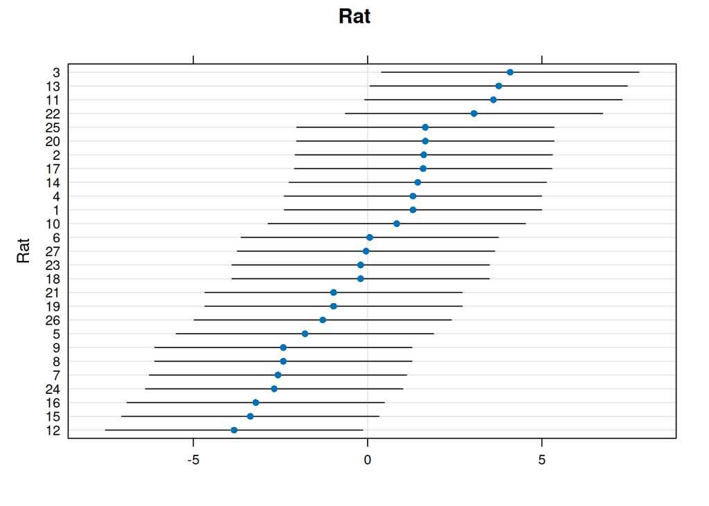

```r
dotplot(ranef(mll_3, condVar=TRUE), strip = FALSE, ylab="Rat")
```

```r
ranef_model_3 <- ranef(mll_3, condVar=TRUE)
```

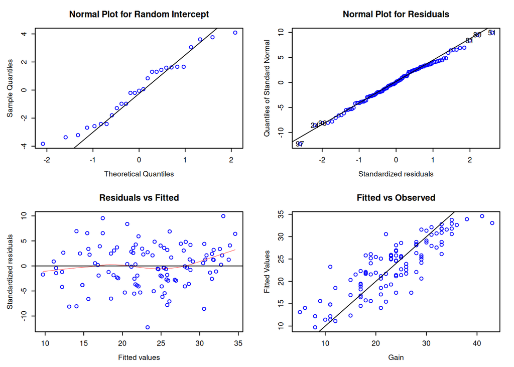

```r
residplot(mll_3)
```

## Model 4 - Numerical Weeks

```r
mll_4 <- lmer(Gain ~ Trt + WeekQ + Trt:WeekQ + (1|Rat), data = rats)
anova(mll_4)
```

```
## Type III Analysis of Variance Table with Satterthwaite's method
##           Sum Sq Mean Sq NumDF  DenDF F value    Pr(>F)
## Trt        36.10   18.05     2 99.322  0.6581    0.5201
## WeekQ      58.08   58.08     1 78.000  2.1178    0.1496
## Trt:WeekQ 696.30  348.15     2 78.000 12.6939 1.688e-05 ***
## ---
## Signif. codes:  0 '***' 0.001 '**' 0.01 '*' 0.05 '.' 0.1 ' ' 1
```

```r
ranova(mll_4)
```

```
## ANOVA-like table for random-effects: Single term deletions
##
## Model:
## Gain ~ Trt + WeekQ + (1 | Rat) + Trt:WeekQ
##           npar  logLik    AIC    LRT Df Pr(>Chisq)
## <none>       8 -334.09 684.18
## (1 | Rat)    7 -337.29 688.58 6.3949  1    0.01145 *
## ---
## Signif. codes:  0 '***' 0.001 '**' 0.01 '*' 0.05 '.' 0.1 ' ' 1
```

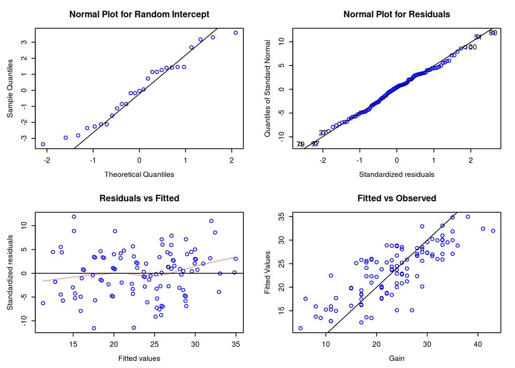

```r
residplot(mll_4)
```

```r
anova(mll_3, mll_4)
```

```
## refitting model(s) with ML (instead of REML)
```

```
## Data: rats
## Models:
## mll_4: Gain ~ Trt + WeekQ + Trt:WeekQ + (1 | Rat)
## mll_3: Gain ~ Trt + factor(Week) + Trt:Week + (1 | Rat)
##       npar    AIC    BIC  logLik -2*log(L)  Chisq Df Pr(>Chisq)
## mll_4    8 695.11 716.57 -339.55    679.11
## mll_3   14 685.93 723.48 -328.96    657.93 21.181  6   0.001702 **
## ---
## Signif. codes:  0 '***' 0.001 '**' 0.01 '*' 0.05 '.' 0.1 ' ' 1
```

### Diagnostic

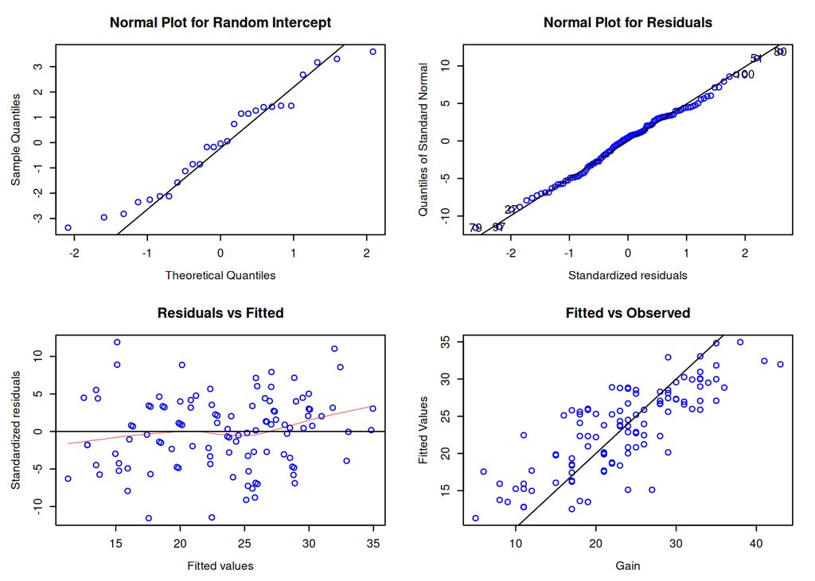

```r
residplot(mll_4)
```

## Comapare

```r
anova(mll_3, mll_4)
```

```
## refitting model(s) with ML (instead of REML)
```

```
## Data: rats
## Models:
## mll_4: Gain ~ Trt + WeekQ + Trt:WeekQ + (1 | Rat)
## mll_3: Gain ~ Trt + factor(Week) + Trt:Week + (1 | Rat)
##       npar    AIC    BIC  logLik -2*log(L)  Chisq Df Pr(>Chisq)
## mll_4    8 695.11 716.57 -339.55    679.11
## mll_3   14 685.93 723.48 -328.96    657.93 21.181  6   0.001702 **
## ---
## Signif. codes:  0 '***' 0.001 '**' 0.01 '*' 0.05 '.' 0.1 ' ' 1
```

# Random effect thinghy

## Create models

```r
## 0) Make sure data is right
rats_df <- as.data.frame(rats)
rats_df$Rat <- factor(as.character(rats_df$Rat))
rats_df$Trt <- factor(as.character(rats_df$Trt))
# Week is fine as factor for the fixed effect
# Ensure WeekQ is numeric
rats_df$WeekQ <- as.numeric(rats_df$WeekQ)


## 1) Compound Symmetry (corCompSymm)
M1 <- lme(Gain ~ WeekQ + Trt + Trt:WeekQ, random = ~ 1 | Rat,
          correlation = corCompSymm(form = ~ WeekQ | Rat),
          data = rats_df)

## 2) AR(1) (corAR1)
M2 <- lme(
  Gain ~ WeekQ + Trt + Trt:WeekQ,
  random = ~ 1 | Rat,
  correlation = corAR1(form = ~ WeekQ | Rat),
  data = rats_df
)

## 3) ARMA(1,1) (corARMA)
M3 <- lme(
  Gain ~ WeekQ + Trt + Trt:WeekQ,
  random = ~ 1 | Rat,
  correlation = corARMA(p = 1, q = 1, form = ~ WeekQ | Rat),
  data = rats_df
)


## 4) Continuous AR(1) (corCAR1)
M4 <- lme(
  Gain ~ WeekQ + Trt + Trt:WeekQ,
  random = ~ 1 | Rat,
  correlation = corCAR1(form = ~ WeekQ | Rat),
  data = rats_df
)


## 5) Exponential spatial (corExp)
M5 <- lme(
  Gain ~ WeekQ + Trt + Trt:WeekQ,
  random = ~ 1 | Rat,
  correlation = corExp(form = ~ WeekQ | Rat),
  data = rats_df
)


## 6) Gaussian spatial (corGaus)
M6 <- lme(
  Gain ~ WeekQ + Trt + Trt:WeekQ,
  random = ~ 1 | Rat,
  correlation = corGaus(form = ~ WeekQ | Rat),
  data = rats_df
)


## 7) Linear spatial (corLin)
M7 <- lme(
  Gain ~ WeekQ + Trt + Trt:WeekQ,
  random = ~ 1 | Rat,
  correlation = corLin(form = ~ WeekQ | Rat),
  data = rats_df
)


## 8) Rational quadratic spatial (corRatio)
M8 <- lme(
  Gain ~ WeekQ + Trt + Trt:WeekQ,
  random = ~ 1 | Rat,
  correlation = corRatio(form = ~ WeekQ | Rat),
  data = rats_df
)


## 9) Spherical spatial (corSpher)
M9 <- lme(
  Gain ~ WeekQ + Trt + Trt:WeekQ,
  random = ~ 1 | Rat,
  correlation = corSpher(form = ~ WeekQ | Rat),
  data = rats_df
)


## 10) Unstructured correlation (corSymm)
M10 <- lme(
  Gain ~ WeekQ + Trt + Trt:WeekQ,
  random = ~ 1 | Rat,
  correlation = corSymm(form = ~ 1 | Rat),
  data = rats_df
)
```

## Compare

```r
models <- list(
  M1 = M1,
  M2 = M2,
  M3 = M3,
  M4 = M4,
  M5 = M5,
  M6 = M6,
  M7 = M7,
  M8 = M8,
  M9 = M9,
  M10 = M10
)

models_names <- c(
  "corCompSymm",
  "corAR1",
  "corARMA",
  "corCAR1",
  "corExp",
  "corGaus",
  "corLin",
  "corRatio",
  "corSpher",
  "corSymm"
)

model_comp <- data.frame(
  Model = names(models),
  Name = models_names,
  AIC  = round(sapply(models, AIC), 2),
  BIC  = round(sapply(models, BIC), 2),
  logLik = round(sapply(models, function(x) logLik(x)[1]), 2)
) %>%
  arrange(AIC)

model_comp
```

```
##     Model        Name    AIC    BIC  logLik
## M2     M2      corAR1 682.57 706.19 -332.28
## M4     M4     corCAR1 682.57 706.19 -332.28
## M5     M5      corExp 682.57 706.19 -332.28
## M8     M8    corRatio 682.66 706.28 -332.33
## M6     M6     corGaus 682.97 706.60 -332.49
## M7     M7      corLin 683.03 706.66 -332.52
## M9     M9    corSpher 683.03 706.66 -332.52
## M10   M10     corSymm 684.01 720.76 -328.01
## M3     M3     corARMA 684.55 710.80 -332.27
## M1     M1 corCompSymm 686.18 709.81 -334.09
```

## Viogram plots

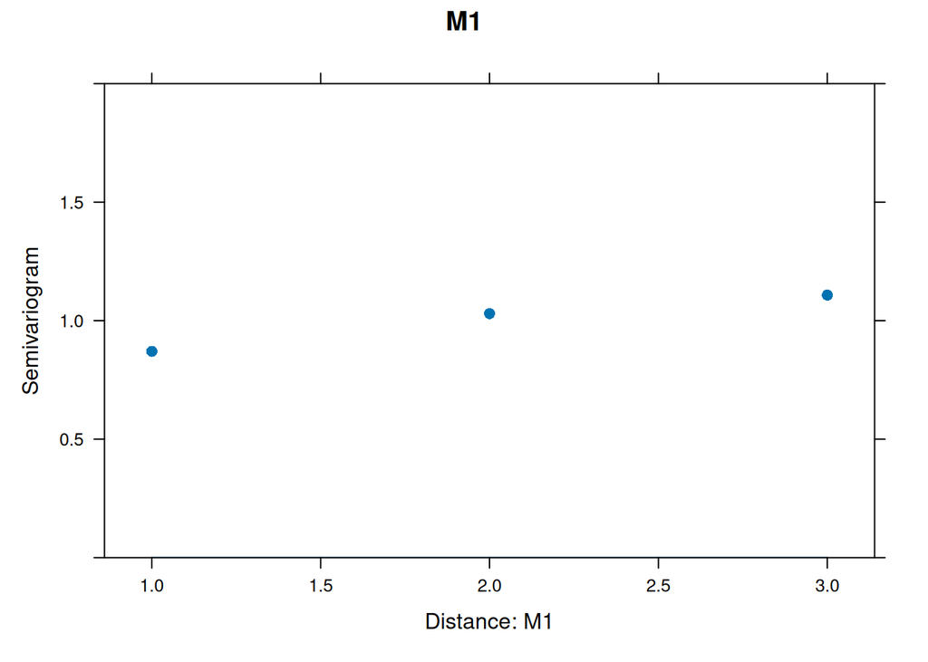

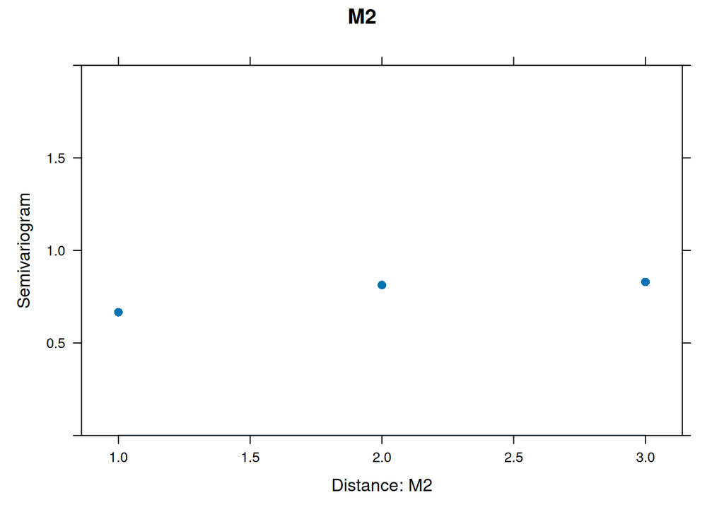

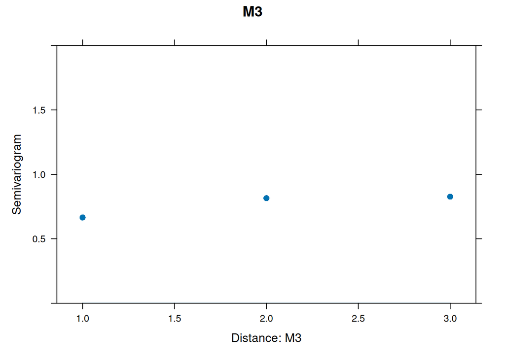

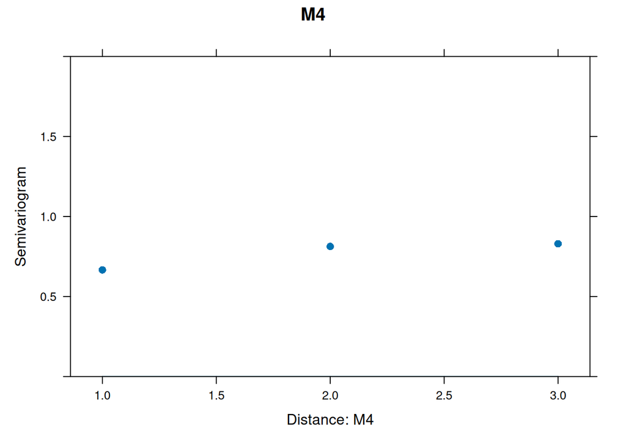

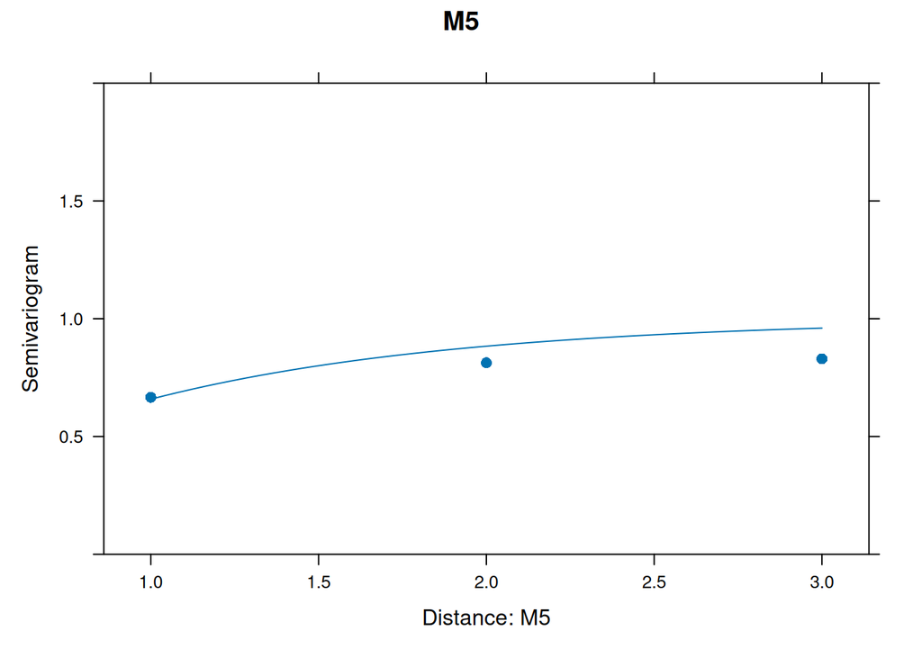

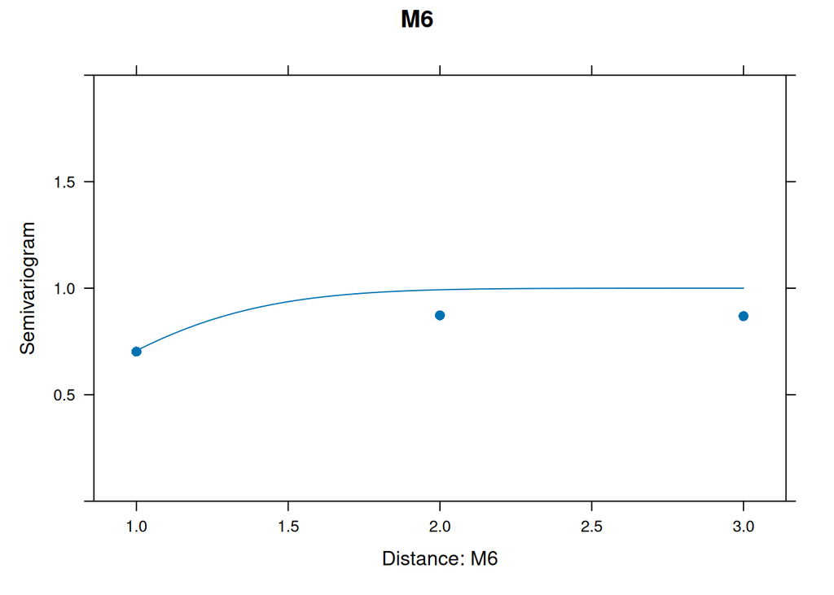

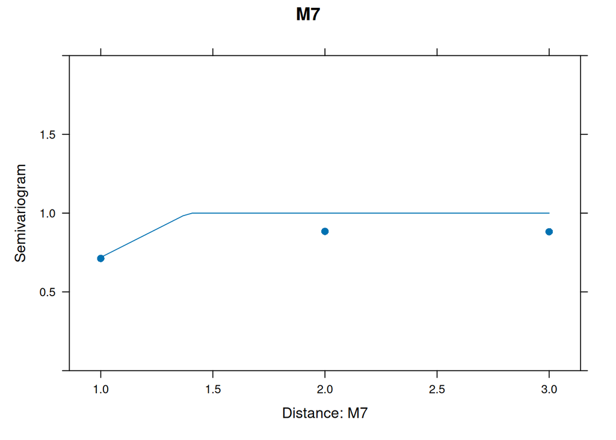

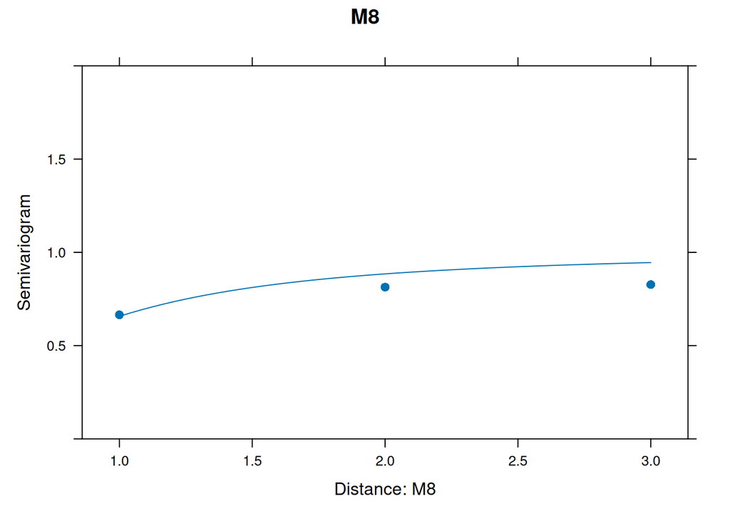

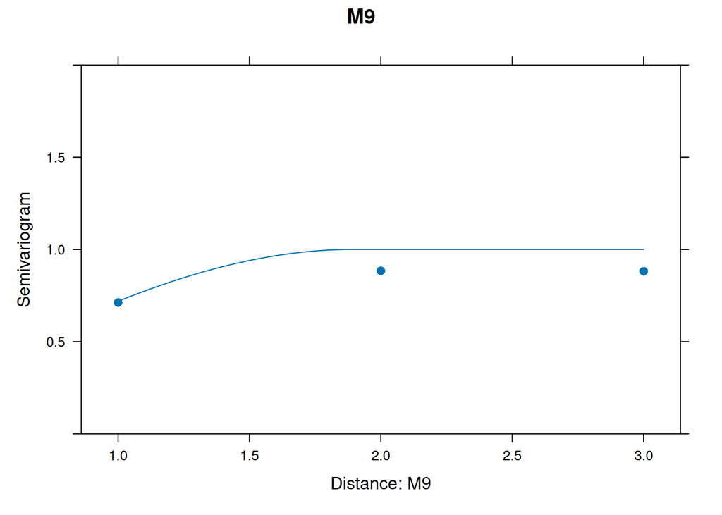

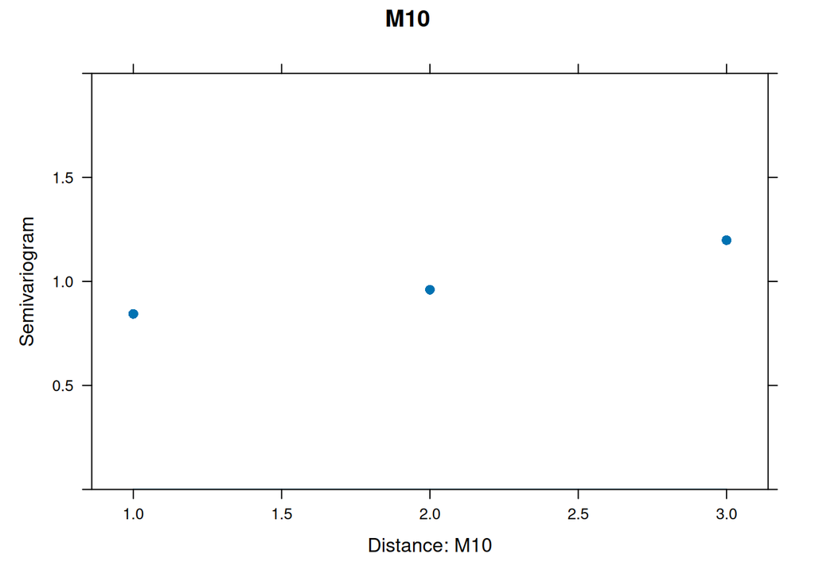

```r
models <- list(
  M1 = M1, M2 = M2, M3 = M3, M4 = M4, M5 = M5,
  M6 = M6, M7 = M7, M8 = M8, M9 = M9, M10 = M10
)

for (name in names(models)) {
  vg <- suppressWarnings(
    Variogram(models[[name]], form = ~ WeekQ | Rat, data = rats_df)
  )

  print(
    plot(
      vg,
      cex = 1,
      pch = 16,
      ylim = c(0, 2),
      xlab = paste("Distance:", name),
      main = name
    )
  )
}
```

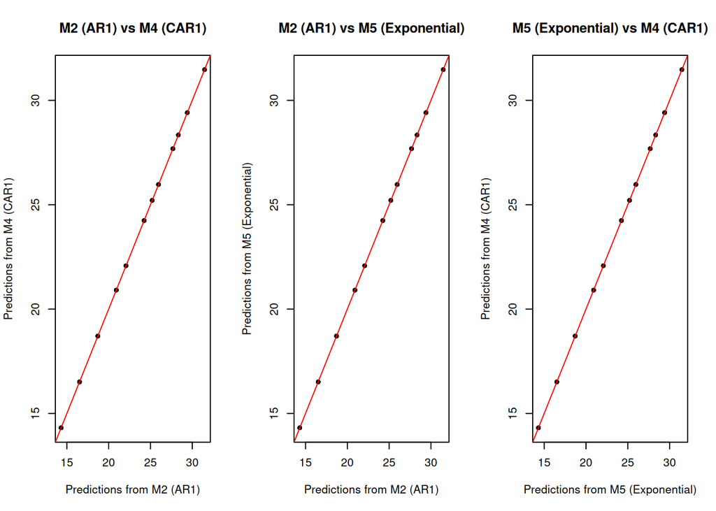

```r
par(mfrow=c(1,3))

## AR1 vs CAR1
plot(predict(M2, Trt=1), predict(M4, Trt=1), pch=20,
     main = "M2 (AR1) vs M4 (CAR1)",
     xlab = "Predictions from M2 (AR1)",
     ylab = "Predictions from M4 (CAR1)")
abline(0,1,col="red")

## AR1 vs Exponential
plot(predict(M2, Trt=1), predict(M5, Trt=1), pch=20,
     main = "M2 (AR1) vs M5 (Exponential)",
     xlab = "Predictions from M2 (AR1)",
     ylab = "Predictions from M5 (Exponential)")
abline(0,1,col="red")

## Exponential vs CAR1
plot(predict(M5, Trt=1), predict(M4, Trt=1), pch=20,
     main = "M5 (Exponential) vs M4 (CAR1)",
     xlab = "Predictions from M5 (Exponential)",
     ylab = "Predictions from M4 (CAR1)")
abline(0,1,col="red")
```

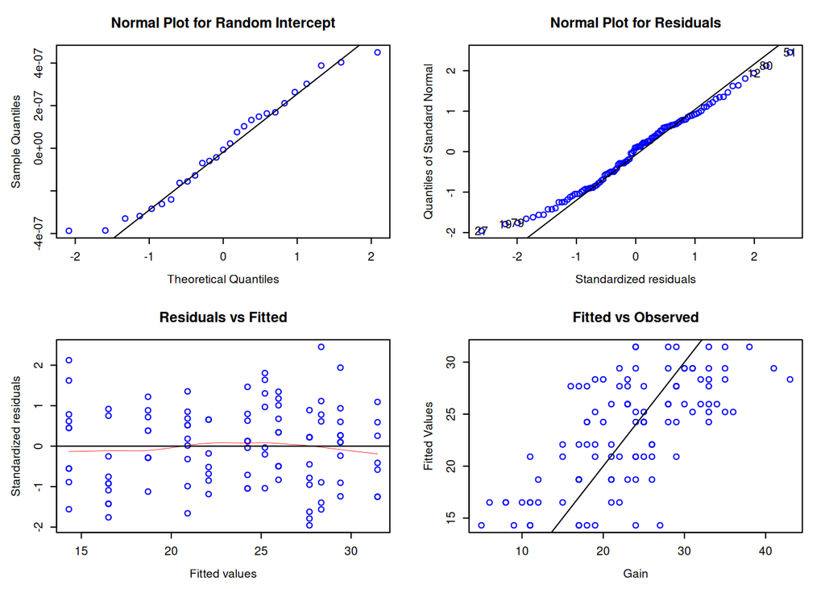

```r
residplot(M2)
```

```r
summary(mll_4)
```

```
## Linear mixed model fit by REML. t-tests use Satterthwaite's method [
## lmerModLmerTest]
## Formula: Gain ~ Trt + WeekQ + Trt:WeekQ + (1 | Rat)
##    Data: rats
##
## REML criterion at convergence: 668.2
##
## Scaled residuals:
##      Min       1Q   Median       3Q      Max
## -2.20651 -0.64414  0.08618  0.63368  2.27120
##
## Random effects:
##  Groups   Name        Variance Std.Dev.
##  Rat      (Intercept)  8.185   2.861
##  Residual             27.427   5.237
## Number of obs: 108, groups:  Rat, 27
##
## Fixed effects:
##             Estimate Std. Error      df t value Pr(>|t|)
## (Intercept)  23.0000     2.2209 99.3220  10.356  < 2e-16 ***
## Trt2         -3.2857     3.4611 99.3220  -0.949 0.344753
## Trt3          0.4500     3.1409 99.3220   0.143 0.886365
## WeekQ         1.4600     0.7406 78.0000   1.971 0.052237 .
## Trt2:WeekQ    1.5257     1.1542 78.0000   1.322 0.190068
## Trt3:WeekQ   -3.9100     1.0474 78.0000  -3.733 0.000358 ***
## ---
## Signif. codes:  0 '***' 0.001 '**' 0.01 '*' 0.05 '.' 0.1 ' ' 1
##
## Correlation of Fixed Effects:
##            (Intr) Trt2   Trt3   WeekQ  Tr2:WQ
## Trt2       -0.642
## Trt3       -0.707  0.454
## WeekQ      -0.834  0.535  0.590
## Trt2:WeekQ  0.535 -0.834 -0.378 -0.642
## Trt3:WeekQ  0.590 -0.378 -0.834 -0.707  0.454
```

```r
# summary(M2)

confint(mll_4)
```

```
## Computing profile confidence intervals ...
```

```
##                   2.5 %    97.5 %
## .sig01       0.99021273  4.187261
## .sigma       4.43894011  6.044844
## (Intercept) 18.74071466 27.259285
## Trt2        -9.92333109  3.351903
## Trt3        -5.57353910  6.473539
## WeekQ        0.01846798  2.901532
## Trt2:WeekQ  -0.72075112  3.772180
## Trt3:WeekQ  -5.94863413 -1.871366
```

```r
intervals(M2, which = 'fixed')
```

```
## Approximate 95% confidence intervals
##
##  Fixed effects:
##                     lower      est.     upper
## (Intercept)  17.591812098 22.521168 27.450525
## WeekQ        -0.002504018  1.721540  3.445584
## Trt2        -11.538307370 -3.574585  4.389137
## Trt3         -6.640608059  0.586352  7.813312
## WeekQ:Trt2   -1.277253823  1.409474  4.096203
## WeekQ:Trt3   -6.359467221 -3.921301 -1.483135
```

Make a table showing the fixed effects estimates, standard errors, t-values, and p-values.

```r
summary(M2)
```

```
## Linear mixed-effects model fit by REML
##   Data: rats_df
##        AIC     BIC    logLik
##   682.5662 706.191 -332.2831
##
## Random effects:
##  Formula: ~1 | Rat
##         (Intercept) Residual
## StdDev: 0.001009555 5.974438
##
## Correlation Structure: AR(1)
##  Formula: ~WeekQ | Rat
##  Parameter estimate(s):
##       Phi
## 0.3414922
## Fixed effects:  Gain ~ WeekQ + Trt + Trt:WeekQ
##                 Value Std.Error DF   t-value p-value
## (Intercept) 22.521168  2.476010 78  9.095752  0.0000
## WeekQ        1.721540  0.865985 78  1.987956  0.0503
## Trt2        -3.574585  3.858582 24 -0.926399  0.3635
## Trt3         0.586352  3.501606 24  0.167452  0.8684
## WeekQ:Trt2   1.409474  1.349540 78  1.044411  0.2995
## WeekQ:Trt3  -3.921301  1.224688 78 -3.201878  0.0020
##  Correlation:
##            (Intr) WeekQ  Trt2   Trt3   WkQ:T2
## WeekQ      -0.874
## Trt2       -0.642  0.561
## Trt3       -0.707  0.618  0.454
## WeekQ:Trt2  0.561 -0.642 -0.874 -0.397
## WeekQ:Trt3  0.618 -0.707 -0.397 -0.874  0.454
##
## Standardized Within-Group Residuals:
##         Min          Q1         Med          Q3         Max
## -1.95596428 -0.83565767  0.09920139  0.67786696  2.45384986
##
## Number of Observations: 108
## Number of Groups: 27
```

```r
library(emmeans) #estimated response values
emmeans(M3, "Trt", by="WeekQ", data=rats)
```

```
## WeekQ = 2.5:
##  Trt emmean   SE df lower.CL upper.CL
##  1     26.8 1.19 26     24.4     29.3
##  2     26.8 1.43 24     23.8     29.7
##  3     17.6 1.19 24     15.2     20.1
##
## Degrees-of-freedom method: containment
## Confidence level used: 0.95
```